# Assignment_4

```r
nrow(valid.df)
```

```
## [1] 121
```

```r
train.df<-train.df[,-9]
valid.df<-valid.df[,-9]
```

Running Naive Bayes Classifier

```r
nb_model <- naiveBayes(Target ~ chest_pain_type + BP_New, data = train.df,1)
valid_pred <- predict(nb_model, valid.df)

# Convert predictions and actual target variable to factors with the same levels
valid.df$Target <- factor(valid.df$Target)
valid_pred <- factor(valid_pred, levels = levels(valid.df$Target))

# Compute confusion matrix
conf_matrix <- confusionMatrix(valid_pred, valid.df$Target,positive = "Yes")
```

```r
conf_matrix
```

```
## Confusion Matrix and Statistics
##
##           Reference
## Prediction No Yes
##        No  96  25
##        Yes  0   0
##
##                Accuracy : 0.7934
##                  95% CI : (0.7103, 0.8616)
##     No Information Rate : 0.7934
##     P-Value [Acc > NIR] : 0.5533
##
##                   Kappa : 0
##
##  Mcnemar's Test P-Value : 1.587e-06
##
##             Sensitivity : 0.0000
##             Specificity : 1.0000
##          Pos Pred Value :    NaN
##          Neg Pred Value : 0.7934
##              Prevalence : 0.2066
##          Detection Rate : 0.0000
##    Detection Prevalence : 0.0000
##       Balanced Accuracy : 0.5000
##
##        'Positive' Class : Yes
##
```

As per the confusion matrix outcomes , the model has achieved an accuracy of 79.34%, but this is misleading due to class imbalance. The Naive Bayes model correctly identifies all non-heart disease cases, a Kappa value of 0. This shows that the model is highly biased towards the majority class and is not suitable for predictions.

Thus, including all attributes improves both Kappa, leading to a better-performing and balanced model.

Running Naive Bayes Classifier including all the attributes. (Validation set)

```r
nb_model_v <- naiveBayes(Target ~., data = train.df)
train_pred_v <- predict(nb_model_v, valid.df)

# Convert predictions and actual target variable to factors with the same levels
valid.df$Target <- factor(valid.df$Target)
train_pred_v <- factor(train_pred_v, levels = levels(valid.df$Target))

# Compute confusion matrix
conf_matrix1_v <- confusionMatrix(train_pred_v, valid.df$Target, positive = "Yes")
conf_matrix1_v
```

```
## Confusion Matrix and Statistics
##
##           Reference
## Prediction No Yes
##        No  90   8
##        Yes  6  17
##
##                Accuracy : 0.8843
##                  95% CI : (0.8135, 0.9353)
##     No Information Rate : 0.7934
##     P-Value [Acc > NIR] : 0.006446
##
##                   Kappa : 0.6363
##
##  Mcnemar's Test P-Value : 0.789268
##
##             Sensitivity : 0.6800
##             Specificity : 0.9375
##          Pos Pred Value : 0.7391
##          Neg Pred Value : 0.9184
##              Prevalence : 0.2066
##          Detection Rate : 0.1405
##    Detection Prevalence : 0.1901
##       Balanced Accuracy : 0.8088
##
##        'Positive' Class : Yes
##
```

ROC Curve

```r
pred_probs_full <- predict(nb_model_v, valid.df, type = "raw")
prob_yes_full <- pred_probs_full[, "Yes"]
roc_full <- roc(valid.df$Target, prob_yes_full)
```

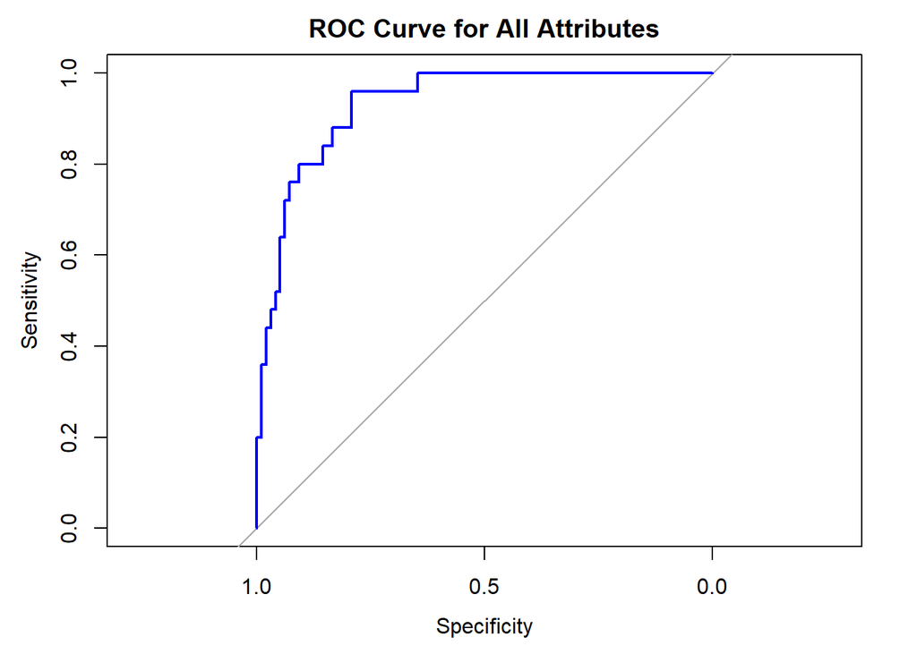

```r
plot(roc_full, col = "blue", main = "ROC Curve for All Attributes")
```

```r
auc_value <- auc(roc_full)
auc_value
```

```
## Area under the curve: 0.9325
```